# projektKoncowy

Kacper Prorok

2023-11-19

# Wprowadzenie

Zbiór danych przedstawia informację o uczniach dwóch szkół średnich, którzy uczęszczali na kursy matematyki. W zbiorze danych znajduje się wiele informacji o otoczeniu ucznia - na przykład: wykształcenie obojga rodziców, czas dojazdu do szkoły, czy uczeń ma dostęp do internetu itp. Dane pochodzą z serwisu *kaggle.com*(https://www.kaggle.com/datasets/uciml/student-alcohol-consumption/data).

## Używane pakiety

```r
library(dplyr)
library(tidyr)
library(ggplot2)
library(mice)
library(corrplot)
library(readr)
```

## Poznajemy dane

Najpierw wczytamy dane

```r
dane <- read_csv("archive (4).zip")
```

```r
head(dane)
```

```
## # A tibble: 6 × 33
##   school sex     age address famsize Pstatus  Medu  Fedu Mjob     Fjob    reason
##   <chr>  <chr> <dbl> <chr>   <chr>   <chr>   <dbl> <dbl> <chr>    <chr>   <chr>
## 1 GP     F        18 U       GT3     A           4     4 at_home  teacher course
## 2 GP     F        17 U       GT3     T           1     1 at_home  other   course
## 3 GP     F        15 U       LE3     T           1     1 at_home  other   other
## 4 GP     F        15 U       GT3     T           4     2 health   servic… home
## 5 GP     F        16 U       GT3     T           3     3 other    other   home
## 6 GP     M        16 U       LE3     T           4     3 services other   reput…
## # ℹ 22 more variables: guardian <chr>, traveltime <dbl>, studytime <dbl>,
## #   failures <dbl>, schoolsup <chr>, famsup <chr>, paid <chr>,
## #   activities <chr>, nursery <chr>, higher <chr>, internet <chr>,
## #   romantic <chr>, famrel <dbl>, freetime <dbl>, goout <dbl>, Dalc <dbl>,
## #   Walc <dbl>, health <dbl>, absences <dbl>, G1 <dbl>, G2 <dbl>, G3 <dbl>
```

```r
dim(dane)
```

```
## [1] 395  33
```

Dane mają 395 rekordów oraz 33 kolumny. Zobaczmy teraz nazwy atrybutów oraz typy danych:

```r
names(dane)
```

```
##  [1] "school"     "sex"        "age"        "address"    "famsize"
##  [6] "Pstatus"    "Medu"       "Fedu"       "Mjob"       "Fjob"
## [11] "reason"     "guardian"   "traveltime" "studytime"  "failures"
## [16] "schoolsup"  "famsup"     "paid"       "activities" "nursery"
## [21] "higher"     "internet"   "romantic"   "famrel"     "freetime"
## [26] "goout"      "Dalc"       "Walc"       "health"     "absences"
## [31] "G1"         "G2"         "G3"
```

```r
class(dane)
```

```
## [1] "spec_tbl_df" "tbl_df"      "tbl"         "data.frame"
```

## Zmienne

Przejdźmy teraz do przyjrzenia się kolumnom, których będę używał w dalszej analizie. Sprawdźmy podstawowe statystyki opisowe:

```r
dane14<-dane%>%
  select(school,age,sex,Mjob,Fjob,studytime,famsup,paid,activities,famrel,freetime,goout,Dalc,Walc,health,absences,G3)
summary(dane14)
```

```
##     school               age           sex                Mjob
##  Length:395         Min.   :15.0   Length:395         Length:395
##  Class :character   1st Qu.:16.0   Class :character   Class :character
##  Mode  :character   Median :17.0   Mode  :character   Mode  :character
##                     Mean   :16.7
##                     3rd Qu.:18.0
##                     Max.   :22.0
##      Fjob             studytime        famsup              paid
##  Length:395         Min.   :1.000   Length:395         Length:395
##  Class :character   1st Qu.:1.000   Class :character   Class :character
##  Mode  :character   Median :2.000   Mode  :character   Mode  :character
##                     Mean   :2.035
##                     3rd Qu.:2.000
##                     Max.   :4.000
##   activities            famrel         freetime         goout
##  Length:395         Min.   :1.000   Min.   :1.000   Min.   :1.000
##  Class :character   1st Qu.:4.000   1st Qu.:3.000   1st Qu.:2.000
##  Mode  :character   Median :4.000   Median :3.000   Median :3.000
##                     Mean   :3.944   Mean   :3.235   Mean   :3.109
##                     3rd Qu.:5.000   3rd Qu.:4.000   3rd Qu.:4.000
##                     Max.   :5.000   Max.   :5.000   Max.   :5.000
##       Dalc            Walc           health         absences
##  Min.   :1.000   Min.   :1.000   Min.   :1.000   Min.   : 0.000
##  1st Qu.:1.000   1st Qu.:1.000   1st Qu.:3.000   1st Qu.: 0.000
##  Median :1.000   Median :2.000   Median :4.000   Median : 4.000
##  Mean   :1.481   Mean   :2.291   Mean   :3.554   Mean   : 5.709
##  3rd Qu.:2.000   3rd Qu.:3.000   3rd Qu.:5.000   3rd Qu.: 8.000
##  Max.   :5.000   Max.   :5.000   Max.   :5.000   Max.   :75.000
##        G3
##  Min.   : 0.00
##  1st Qu.: 8.00
##  Median :11.00
##  Mean   :10.42
##  3rd Qu.:14.00
##  Max.   :20.00
```

Przyjrzymy się teraz dokładniej zmiennym, które podejrzewam że powinny zostać zmienione na typ faktor.

1. zmienna `school`

```r
table(dane14$school)
```

```
##
##  GP  MS
## 349  46
```

```r
dane$school<-as.factor(dane$school)
```

Zmienna `school` mówi nam do jakiej szkoły chodził uczeń. Widzimy, że szkoła *GP* (Gabriel Pereira) jest dużo bardziej liczna od szkoły *MS*(Mousinho da Silveira). Odrazu zadajmy pytanie: jaka szkoła miała wyższą ocenę końcową `G3`:

```r
dane14%>%
  select(G3,school)%>%
  group_by(school)%>%
    summarise(średnia=mean(G3),
            odchylenie=sd(G3),
            mediana=median(G3),
            )
```

```
## # A tibble: 2 × 4
##   school średnia odchylenie mediana
##   <chr>    <dbl>      <dbl>   <dbl>
## 1 GP       10.5        4.63      11
## 2 MS        9.85       4.24      10
```

2. zmienna `sex`

```r
table(dane14$sex)
```

```
##
##   F   M
## 208 187
```

Mamy tutaj podobne liczności obu płci.

3. zmienna `Mjob` oraz `Fjob`

```r
table(dane14$Mjob)
```

```
##
##  at_home   health    other services  teacher
##       59       34      141      103       58
```

```r
table(dane14$Fjob)
```

```
##
##  at_home   health    other services  teacher
##       20       18      217      111       29
```

Zmienne te zawierają informację o tym gdzie pracuje matka oraz ojciec ucznia.

4. `studytime` - dokładniej zajmuję się nią w późniejszych rozważaniach.
5. `famsup`,`paid` oraz `activities`

Są to zmienne typu binarnego (*yes* albo *no*). `famsup` mówi nam o tym, czy uczeń otrzymywał wsparcie naukowe od swojej rodziny, `paid` czy uczeń chodził na płatne zajęcia z przedmiotu, a `activities` czy uczęszczał na jakieś dodatkowe aktywności. Sprawdźmy zatem liczności:

```r
table(dane14$famsup)
```

```
##
##  no yes
## 153 242
```

```r
table(dane14$paid)
```

```
##
##  no yes
## 214 181
```

```r
table(dane14$activities)
```

```
##
##  no yes
## 194 201
```

**Wszystkie zmienne powyżej powinny zostać zmienione na typ factor bez nadania kolejności. Będę robił to w trakcie późniejszych rozważań.**

6. `famrel`

```r
table(dane14$famrel)
```

```
##
##   1   2   3   4   5
##   8  18  68 195 106
```

Mówi nam o ocenie relacji z rodzicami w skali od 1 do 5. Zmienię typ na factor i nadam rangi poszczególnym klasom:

```r
dane$famrel<-as.factor(dane$famrel)
levels(dane$famrel)<-c("1","2","3","4","5")
```

7. `goout`

Zawiera informację o częstotliwości wyjścia ze znajomymi. Ponownie skala jest od 1 do 5. Nadaję kolejność:

```r
dane$goout<-as.factor(dane$goout)
levels(dane$goout)<-c("1","2","3","4","5")
```

8. `Dalc` oraz `Walc`

`Dalc` mówi nam o konsumpcji alkoholu w tygodniu, a `Walc` w weekendy. Nadaje kolejności:

```r
dane$Dalc<-as.factor(dane$Dalc)
levels(dane$Dalc)<-c("1","2","3","4","5")

dane$Walc<-as.factor(dane$Walc)
levels(dane$Walc)<-c("1","2","3","4","5")
```

1. `health`

Zdrowie ucznia w skali 1-5. Ponownie nadajemy kolejności:

```r
dane$health<-as.factor(dane$health)
levels(dane$health)<-c("1","2","3","4","5")
```

**Warto zapamiętać, że kategoria 1 oznacza bardzo mało, a kategoria 5 - bardzo dużo.** W późniejszym etapie staram się opisać szczegółowiej każdy atrybut.

Przejdźmy teraz do zmiennych, które są ilościowe, czyli zmienna `age` oraz `G3`. Zmienną `G3` dokładniej obejrzę potem, narazie zajmijmy się zmienną `age`.

```r
summary(dane$age)
```

```
##    Min. 1st Qu.  Median    Mean 3rd Qu.    Max.
##    15.0    16.0    17.0    16.7    18.0    22.0
```

Średnio uczniowie z naszych danych mają prawie 17 lat. Najmłodszy uczeń ma lat 15, a najstarszy 22.

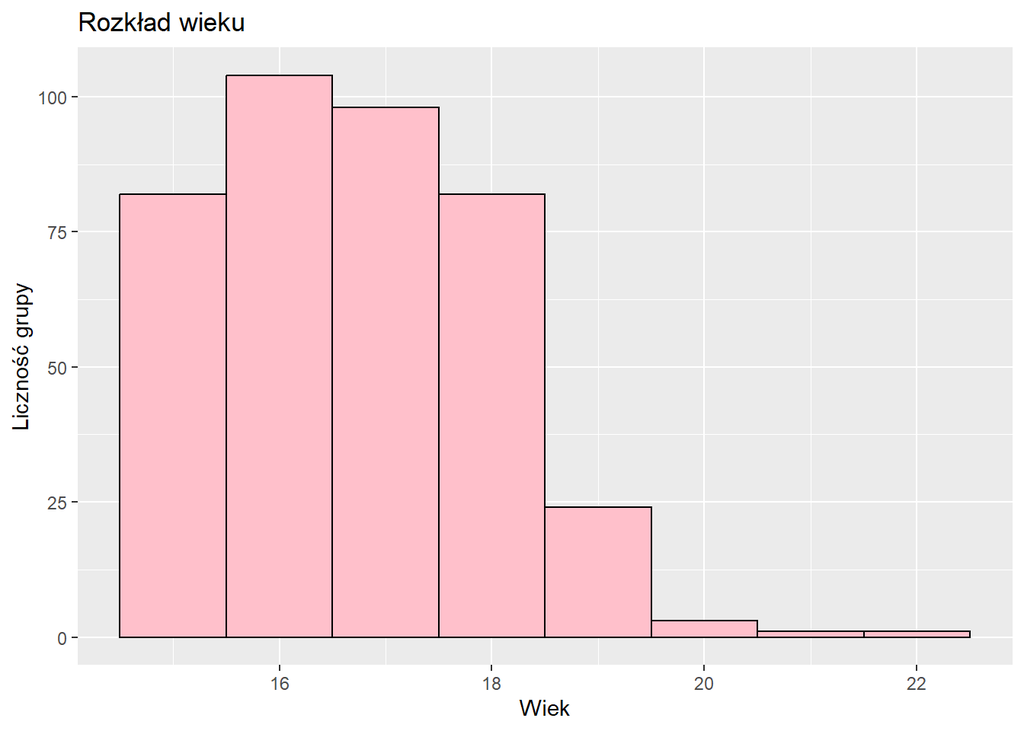

```r
ggplot()+
  geom_histogram(mapping=aes(x=dane$age),
                 bins=8,
                 color="black",
                 fill="pink")+
  labs(title ="Rozkład wieku",
       x="Wiek",
       y="Liczność grupy")
```

Widzimy, że zdecydowana większość uczniów ma mniej niż 18. Nic dziwnego, skoro badamy szkołę średnią. Można zadać pytanie, co robią tam osoby starsze.W naszych danych znajduje się jeszcze zmienna `failures`, która mówi nam ile razy uczeń powtarzał klasę. Sprawdźmy zatem czy uczniowie powyżej 18 roku życia znajdują się w naszym zestawie z powodu nie zaliczenia klasy.

```r
table(dane$failures,dane$age)
```

```
##
##     15 16 17 18 19 20 21 22
##   0 71 88 84 63  5  1  0  0
##   1  3 10  8 16 13  0  0  0
##   2  5  4  2  1  3  2  0  0
##   3  3  2  4  2  3  0  1  1
```

```r
cor(dane$failures,dane$age)
```

```
## [1] 0.2436654
```

**Istnieje słaba zależność między wiekiem, a ilością powtarzanych klas.**

Teraz przyjrzymy się jak wygląda atrybut `G3`, który przedstawia końcową ocenę ucznia

```r
summary(dane$G3)
```

```
##    Min. 1st Qu.  Median    Mean 3rd Qu.    Max.
##    0.00    8.00   11.00   10.42   14.00   20.00
```

`G3` jest z przedziału 0-20, a średnia wynosi 10.42.

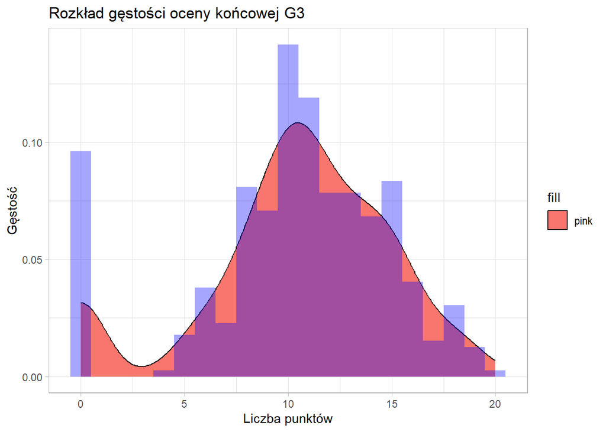

```r
dane%>%
  ggplot()+
  geom_density(aes(x=G3,fill="pink"))+
  geom_histogram(aes(x=G3,y=..density..),
                 binwidth = 1,
                 fill="blue",
                 alpha=0.35)+
  labs(title = "Rozkład gęstości oceny końcowej G3",
       x="Liczba punktów",
       y="Gęstość")+
  theme_light()
```

Większość obserwacji znajduje się przy 10, ale widzimy również spory wzrost obserwacji przy zbliżaniu się do 0.

# Pytania badawcze

## Czy wykształcenie rodziców ma wpływ na wynik końcowy

Zaczniemy od wpływu wykształcenia obojga rodziców. Przyjrzyjmy się kolumnom `Fedu`(wykształcenie ojca) oraz `Medu`(wykształcenie matki). Zawierają one dane o poziomie wykształcenia rodzica, gdzie:

- 0 = brak wykształcenia
- 1 = od 1 do 4 klasy szkoły podstawowej
- 2 = wykształcenie podstawowe
- 3 = wykształcenie średnie
- 4 = wykształcenie wyższe

Wyodrębnie teraz z tabelki dane tylko potrzebne nam atrybuty:

```r
dane1<-dane%>%
  select(Medu,Fedu,G3,Mjob,Fjob)
```

Zobaczmy najpierw jak wyglada wykształcenie matek w naszych danych:

```r
table(dane1$Medu)
```

```
##
##   0   1   2   3   4
##   3  59 103  99 131
```

A teraz ojców:

```r
table(dane1$Fedu)
```

```
##
##   0   1   2   3   4
##   2  82 115 100  96
```

Czyli mamy więcej matek z co najmniej średnim wykształceniem. Zobaczmy więc jakie zawody głównie wykonują matki:

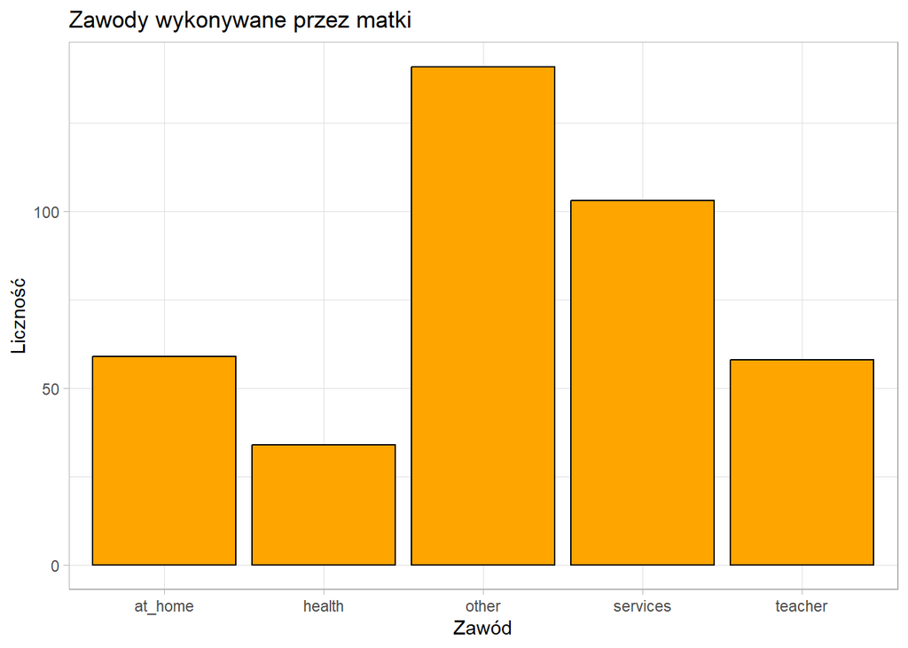

```r
dane2<-dane1%>%
  select(Mjob)%>%
  group_by(Mjob)%>%
  count()%>%
  rename("job"=Mjob,"Mjob"=n)

dane3<-dane1%>%
  select(Fjob)%>%
  group_by(Fjob)%>%
  count()

dane2<-cbind(dane2,"Fjob"=dane3$n)
ggplot(dane2, aes(x = factor(job), y =Mjob)) +
  geom_col(fill="orange",
           color="black")+
  labs(title = "Zawody wykonywane przez matki",
       x="Zawód",
       y="Liczność")+
  theme_light()
```

A teraz narysujmy wykres dla ojców:

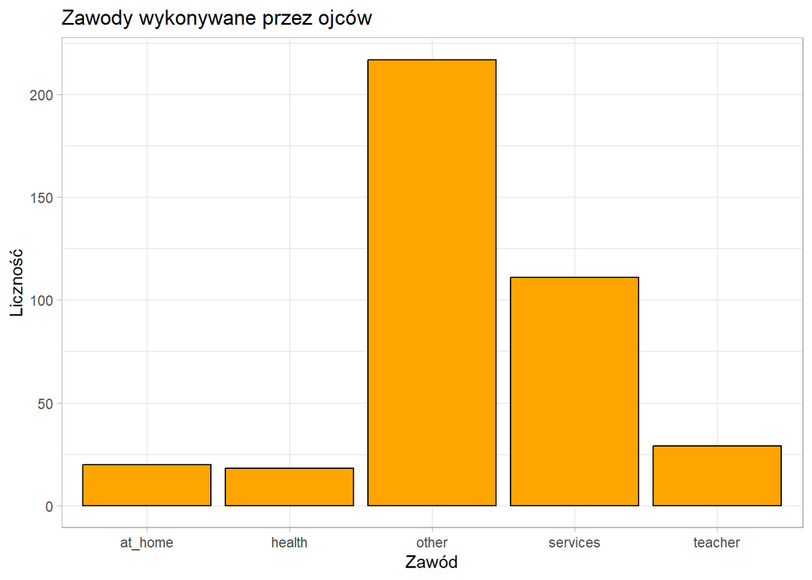

```r
ggplot(dane2, aes(x = factor(job), y =Fjob)) +
  geom_col(fill="orange",
           color="black")+
  labs(title = "Zawody wykonywane przez ojców",
       x="Zawód",
       y="Liczność")+
  theme_light()
```

Zdecydowanie mniej ojców zostaje w domu oraz dużo mniej pracuje w sektorze zdrowia lub jako nauczyciel, co może mieć związek z gorszym wykształceniem posiadanych przez ojców. Sprawdźmy zatem, czy faktycznie wykształcenie ma wpływ na wykonywany przez matki zawód:

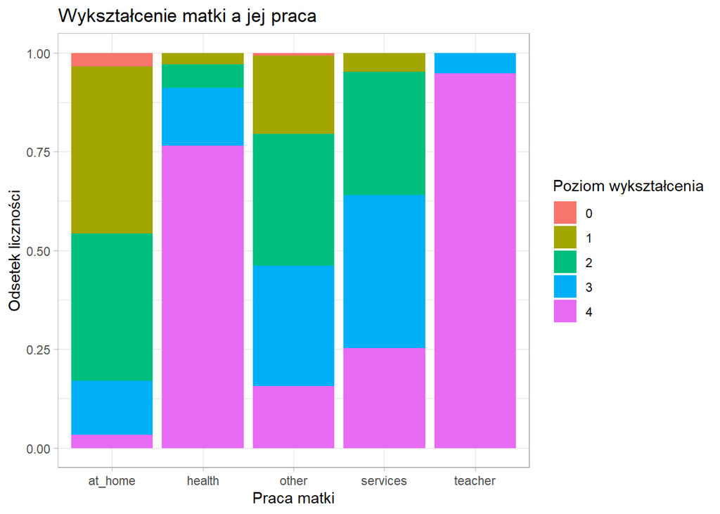

```r
ggplot()+
  geom_bar(aes(x=dane1$Mjob,fill=factor(dane1$Medu)),
           position = "fill")+
  theme_light()+
  labs(title = "Wykształcenie matki a jej praca",
       x="Praca matki",
       y="Odsetek liczności",
       fill="Poziom wykształcenia")
```

**Matki które pracują jako nauczycielki lub pracują w medycynie w przeważającej części mają wykształcenie wyższe.** Kolejne wnioski, jakie można wysnuć z wykresu to to, że **większość matek, które zostają w domu, ma gorsze wykształcenie.**

Teraz wykres dla ojców:

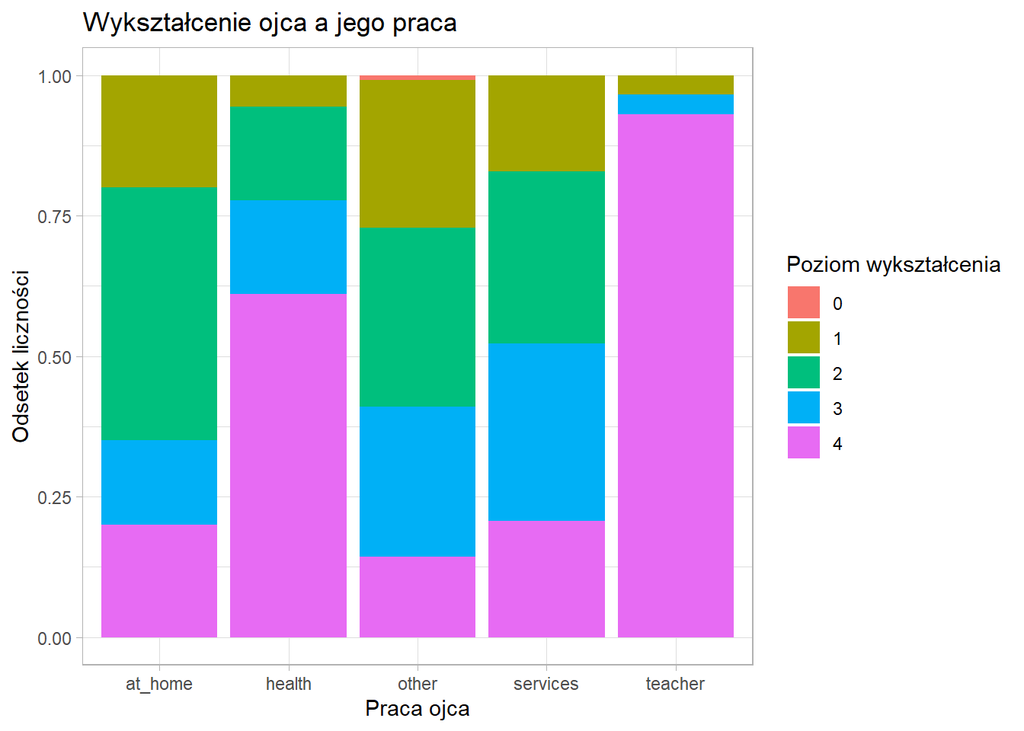

```r
ggplot()+
  geom_bar(aes(x=dane1$Fjob,fill=factor(dane1$Fedu)),
           position = "fill")+
  theme_light()+
  labs(title = "Wykształcenie ojca a jego praca",
       x="Praca ojca",
       y="Odsetek liczności",
       fill="Poziom wykształcenia")
```

Przejdźmy do sprawdzenia czy poziom wykształcenia rodziców wpływa na ocenę końcową `G3`. Stworzę zmienną `wyksztalcenie`, która będzie średnim wykształceniem ojca i matki:

```r
dane4<-dane%>%
  select(G3,Medu,Fedu,famrel)%>%
  mutate("wyksztalcenie"=(as.numeric(Medu)+as.numeric(Fedu))/2)
```

Zanim przedstawimy dane na wykresie sprawdźmy liczności stworzonych przeze mnie grup:

```r
table(dane4$wyksztalcenie)
```

```
##
## 0.5   1 1.5   2 2.5   3 3.5   4
##   2  39  43  72  47  64  58  70
```

Widzimy, że grupa z wykształceniem “0.5” ma tylko dwie obserwacje, więc wliczę ją do grupy 1.0, aby nie zakłamywała wyników.

```r
dane4<-dane4%>%
  mutate(wyksztalcenie=ifelse(wyksztalcenie==0.5,1,wyksztalcenie))
```

Zobaczymy teraz czy istneją jakieś zależności między oceną końcową, a średnim wykształceniem rodziców (aby wykres był czytelny pokażę tylko najgorsze oraz najlepsze wykształcenie)

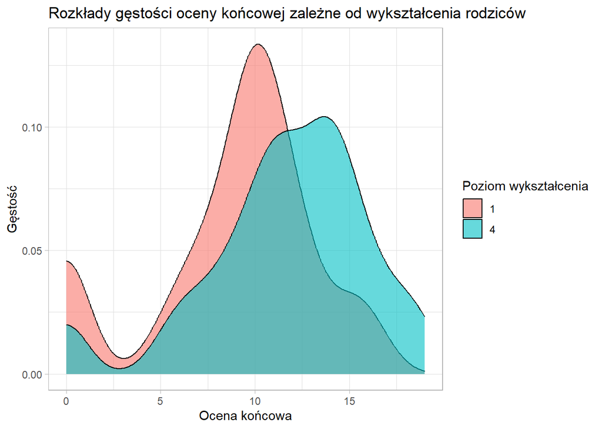

```r
dane4%>%
  filter(wyksztalcenie==1|wyksztalcenie==4)%>%
ggplot()+
  geom_density(aes(x=G3,fill=factor(wyksztalcenie)),
               alpha=0.6)+
  theme_light()+
  labs(title = "Rozkłady gęstości oceny końcowej zależne od wykształcenia rodziców",
       x="Ocena końcowa",
       y="Gęstość",
       fill="Poziom wykształcenia")
```

**Istneje dosyć wyraźna różnica między oceną końcową, a wykształceniem rodziców.**

Widzimy, że dla wykształcenia =4 ocena `G3` najczęściej występuje w okolicach 12-14, a dla wykształcenia =1 większość wyników skupia się w okolicach 10. Dodatkowo dla słabszego wykształcenia dużo więcej uczniów miało ocenę końcową w okolicah 0 punktów.

## Czy zawód wykonywany przez rodzica ma wpływ na ocenę końcową

Najpierw zobaczmy jak sytuacja wygląda dla zawodu matki:

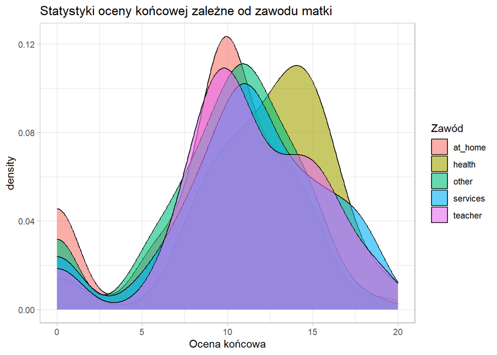

```r
ggplot(dane)+
  geom_density(aes(x=G3,fill=dane$Mjob),
               alpha=0.6)+
  theme_light()+
  labs(title = "Statystyki oceny końcowej zależne od zawodu matki",
       x="Ocena końcowa",
       fill="Zawód")
```

**Uczniowie, których matka pracowała w sektorze zdrowotnym uzykiwali lepsze oceny końcowe**

A teraz dla ojca:

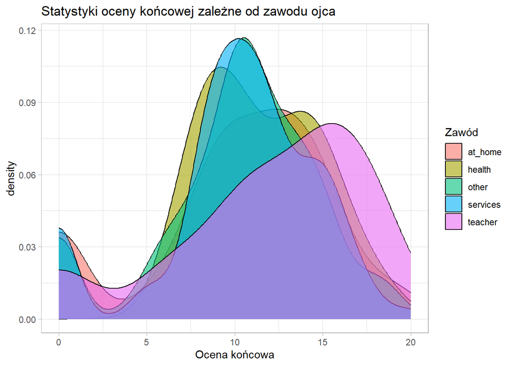

```r
ggplot(dane)+
  geom_density(aes(x=G3,fill=dane$Fjob),
               alpha=0.6)+
  theme_light()+
  labs(title = "Statystyki oceny końcowej zależne od zawodu ojca",
       x="Ocena końcowa",
       fill="Zawód")
```

**Zdecydowanie najlepiej wypadli uczniowie, których ojciec jest nauczycielem,** a reszta grup uzykała bardzo podobne wyniki końcowe.

*Należy zwrócić uwagę, że na wyniki napewno wpływa też wykształcenie rodzica, co zbadaliśmy w poprzednim pytaniu.*

## Czy separacja rodziców wpływa na spożycie alkoholu przez dziecko oraz na ocenę końcową

Sprawdźmy, czy rodzice którzy nie mieszkają z dzieckiem mają wpływ na ilość spożywanego alkoholu przez dziecko. Do zbadania tego przyda nam się atrybut `Pstatus`, który przyjmuje wartość `T` jeśli rodzice mieszkają razem, oraz wartość `A`, jeśli mieszkają osobno.

Zmienię typ zmiennej na factor oraz sprawdzę liczności dwóch grup:

```r
dane$Pstatus<-as.factor(dane$Pstatus)
dane5<-dane%>%
  group_by(Pstatus)%>%
  count()
dane5
```

```
## # A tibble: 2 × 2
## # Groups:   Pstatus [2]
##   Pstatus     n
##   <fct>   <int>
## 1 A          41
## 2 T         354
```

Jak widzimy liczność próbki `A` jest dużo mniejsza od `T`, ale nadal jest to 40 obserwacji więc wyniki nie powinny być zakłamane. Obliczmy teraz statystyki opisowe:

```r
dane5<-dane%>%
  select(Pstatus,Dalc,Walc)%>%
  mutate("spozycie"=as.numeric(Dalc)+as.numeric(Walc))%>%
  group_by(Pstatus)%>%
  summarise(średnia=mean(spozycie),
            odchylenie=sd(spozycie),
            mediana=median(spozycie),
            )
dane5
```

```
## # A tibble: 2 × 4
##   Pstatus średnia odchylenie mediana
##   <fct>     <dbl>      <dbl>   <dbl>
## 1 A          3.83       2.35       3
## 2 T          3.77       1.94       3
```

**Nie ma zależności między separacją rodziców, a spożyciem alkoholu przez dziekco.**

Sprawdźmy jeszcze jaka będzie sytuacja dla oceny końcowej`G3`

```r
dane5<-dane%>%
  select(G3,Pstatus)%>%
  group_by(Pstatus)%>%
  summarise(średnia=mean(G3),
            odchylenie=sd(G3),
            mediana=median(G3),
            )
dane5
```

```
## # A tibble: 2 × 4
##   Pstatus średnia odchylenie mediana
##   <fct>     <dbl>      <dbl>   <dbl>
## 1 A          11.2       4.29      11
## 2 T          10.3       4.61      11
```

**Dość niespodziewanie, ale lepiej wypadli tutaj uczniowie których rodzice żyli osobno.**

## Wyjścia ze znajomymi a spożycie alkoholu

Sprawdźmy jak wyglądają zmienne `Dalc` i `Walc`, które zawierają informacje o spożyciu alkoholu w tygodniu i w weekend.

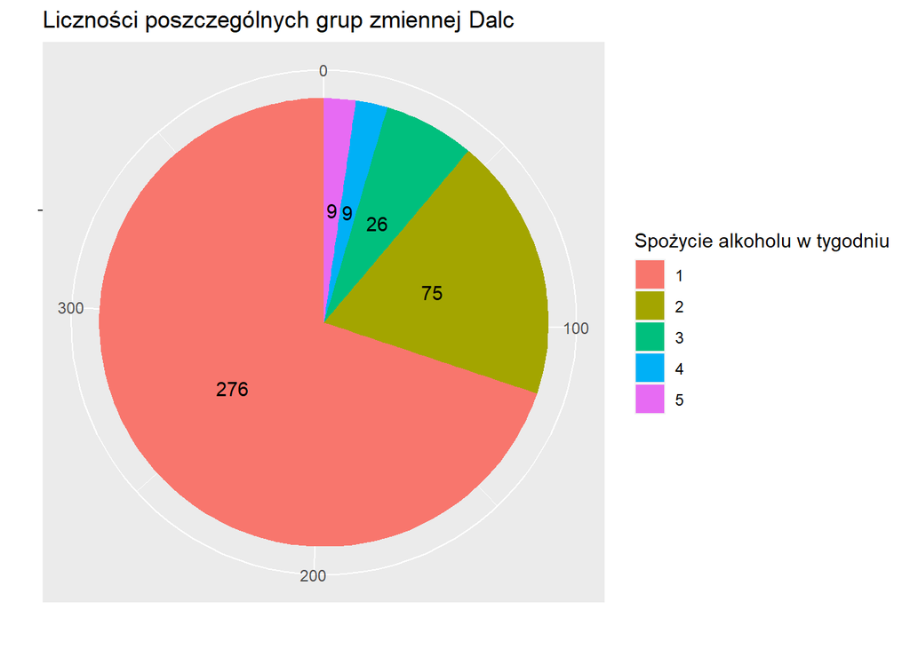

```r
dane19<-dane%>%
  group_by(Dalc)%>%
  count()

ggplot(dane19,aes(x="",y=n,fill=Dalc))+
  geom_col()+
  geom_text(aes(label = n),
            position = position_stack(vjust = 0.5)) +
  coord_polar(theta = "y")+
  labs(title = "Liczności poszczególnych grup zmiennej Dalc",
       x="",
       y="",
       fill="Spożycie alkoholu w tygodniu")
```

Zmienna `Dalc` jest zmienną jakościową, która mówi nam o spożyciu alkoholu przez ucznia w tygodniu - 1 to bardzo mało, a 5 to bardzo dużo. Jak widzimy najwięcej studentów znajduje się w grupie ‘1’, czyli tej najmniej spożywającej alkohol. Zobaczmy czy sytuacja ulegnie zmianie w weekend:

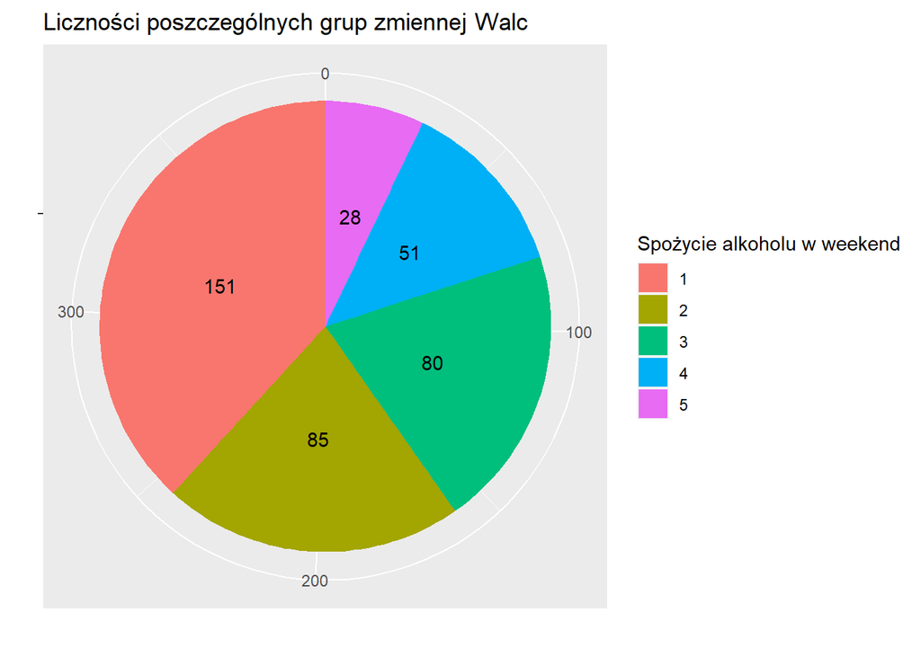

```r
dane20<-dane%>%
  group_by(Walc)%>%
  count()

ggplot(dane20,aes(x="",y=n,fill=Walc))+
  geom_col()+
  geom_text(aes(label = n),
            position = position_stack(vjust = 0.5)) +
  coord_polar(theta = "y")+
  labs(title = "Liczności poszczególnych grup zmiennej Walc",
       x="",
       y="",
       fill="Spożycie alkoholu w weekend")
```

Sytuacja ulega mocnej zmianie - **dużo więcej uczniów spożywa alkohol w weekend**. W naszych danych pojawia się jeszcze jedna zmienna - `goout`, która mówi nam o tym, jak często uczeń wychodzi ze znajomymi. Zobaczmy czy między spożyciem alkoholu, a wyjsciami ze znajomymi występuje jakaś zależność. Do sprawdzenia tego stworzę uśrednioną zmienną `spozycie`, która będzie średnią zmiennych `Dalc` i `Walc`.

```r
dane6<-dane%>%
  select(Dalc,Walc,absences,goout)%>%
  mutate("spozycie"=(as.numeric(Dalc)+as.numeric(Walc))/2)


table(dane6$spozycie,dane6$goout)
```

```
##
##        1  2  3  4  5
##   1   15 53 47 26  9
##   1.5  3 21 30  7  5
##   2    2 14 26 11  7
##   2.5  2  7 15 17  4
##   3    0  4  5 15 11
##   3.5  1  2  4  3  7
##   4    0  0  1  5  3
##   4.5  0  1  0  2  1
##   5    0  1  2  0  6
```

Stwórzmy jeszcze wykres zależności:

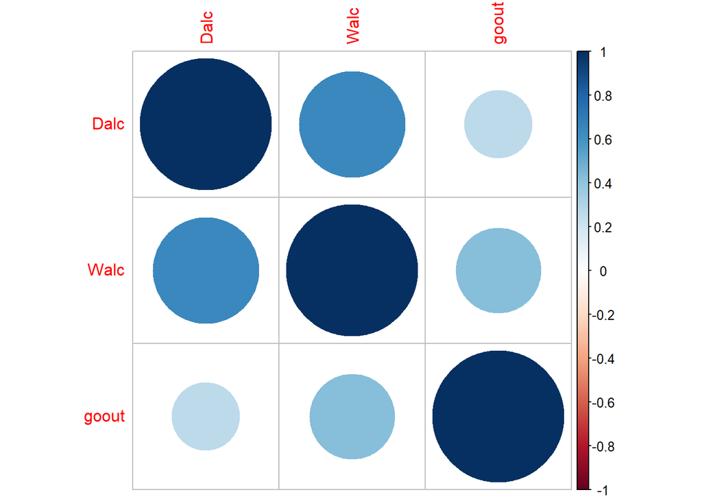

```r
dane17<-dane%>%
  select(Dalc,Walc,goout)%>%
  mutate(Dalc=as.numeric(Dalc),Walc=as.numeric(Walc),goout=as.numeric(goout))
cor=cor(dane17[,c("Dalc","Walc","goout")],
        method="pearson")

corrplot(cor)
```

**Występuje niewielka zależność między spożyciem alkoholu a wyjściami ze znajomymi.** Co cieawe jest ona troszkę silniejsza w weekendy.

**Umiarkowana zależność występuje między spożywaniem alkoholu w weekend i w tygodniu**, co może świadczyć o tym, że duża część pijących w weekend również będzie piła w tygodniu.

## Spożycie alkoholu a ocena końcowa G3:

Zanim zaczniemy musimy zwrócić uwagę na liczności poszczególnych grup:

```r
table(dane$Dalc)
```

```
##
##   1   2   3   4   5
## 276  75  26   9   9
```

Dla dużego i bardzo dużego spożycia alkoholu statystki mogą przekłamywać wyniki, dlatego połączmy grupę 4 oraz 5 z grupą 3.

```r
dane8<-dane%>%
  select(Dalc,G3)%>%
  mutate(Dalc=ifelse(Dalc==4|Dalc==5|Dalc==3,3,Dalc))
```

Sporządźmy wykres:

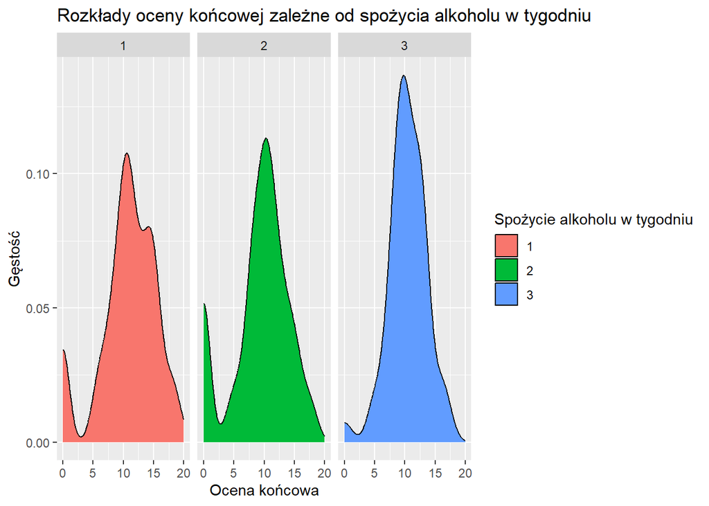

```r
ggplot(data = dane8,
       aes(x=G3, fill=factor(Dalc))) +
  geom_density(stat="density") +
  facet_grid(. ~ Dalc)+
  labs(title = "Rozkłady oceny końcowej zależne od spożycia alkoholu w tygodniu",
       x="Ocena końcowa",
       y="Gęstość",
       fill="Spożycie alkoholu w tygodniu")
```

Statystyki opisowe:

```r
dane9<-dane8%>%
  select(G3,Dalc)%>%
  group_by(Dalc)%>%
  summarise(liczba = n(),
            srednia = mean(G3),
            mediana = median(G3),
            odch.st = sd(G3))
dane9
```

```
## # A tibble: 3 × 5
##    Dalc liczba srednia mediana odch.st
##   <dbl>  <int>   <dbl>   <dbl>   <dbl>
## 1     1    276   10.7       11    4.68
## 2     2     75    9.25      10    4.81
## 3     3     44   10.4       10    3.10
```

Zdecydowanie najgorzej poszło grupie `2`, która miała umiarkowane spożycie alkholou, a tylko trochę lepiej od grupy spożywającej dużo alkhololu, poradziła sobie grupa `1`.

**Zależność między spożyciem alkoholu w tygodniu, a oceną końcową jest mała.**

Zobaczmy czy sytuacja zmienia się, gdy weźmiemy spożycie alkholu w weekend.

```r
dane10<-dane%>%
  select(G3,Walc)%>%
  group_by(Walc)%>%
  summarise(liczba = n(),
            srednia = mean(G3),
            mediana = median(G3),
            odch.st = sd(G3))
dane10
```

```
## # A tibble: 5 × 5
##   Walc  liczba srednia mediana odch.st
##   <fct>  <int>   <dbl>   <dbl>   <dbl>
## 1 1        151   10.7       11    5.13
## 2 2         85   10.1       11    4.95
## 3 3         80   10.7       10    3.70
## 4 4         51    9.69      10    3.62
## 5 5         28   10.1       10    4.13
```

**Tutaj również nie ma silnej zależności między spożyciem alkoholou w weekend, a oceną końcową.**

## Czy ilość spożywanego alkoholu wpływa na zdrowie

Przyjrzymy się teraz zmiennej `health`, która mówi nam o poziomie zdrowia ucznia (1-najgorszy,5-najlepszy). Sprawdźmy najpierw stan zdrowia naszych uczniów:

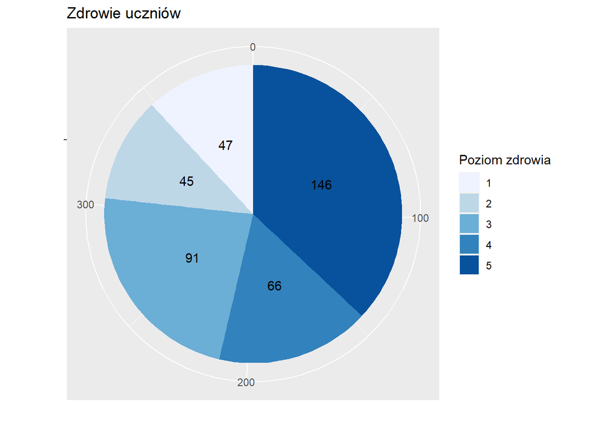

```r
dane18<-dane%>%
  group_by(health)%>%
  count()

ggplot(dane18,aes(x="",y=n,fill=health))+
  geom_col()+
  geom_text(aes(label = n),
            position = position_stack(vjust = 0.5)) +
  coord_polar(theta = "y")+
  scale_fill_brewer()+
  labs(title = "Zdrowie uczniów",
       x="",
       y="",
       fill="Poziom zdrowia")
```

*146 uczniów oceniło swój stan zdrowia na najlepszy, a więcej niż połowa uczniów ma co najmniej dobry(`4`) stan zdrowia.*

Do moich rozważań podzielę zmienną `health` w następujący sposób: uczniowie którzy ocene zdrowia mają mniejszą lub równą 3 połączę w jedną grupę i nazwę *“zły”*, a resztę połączę w grupę *“dobry”*:

```r
dane11<-dane%>%
  select(G3,Walc,health)%>%
  mutate(health=ifelse(health==1|health==2|health==3,"zły","dobry"))
```

Sprawdźmy teraz jak wygląda stan zdrowia:

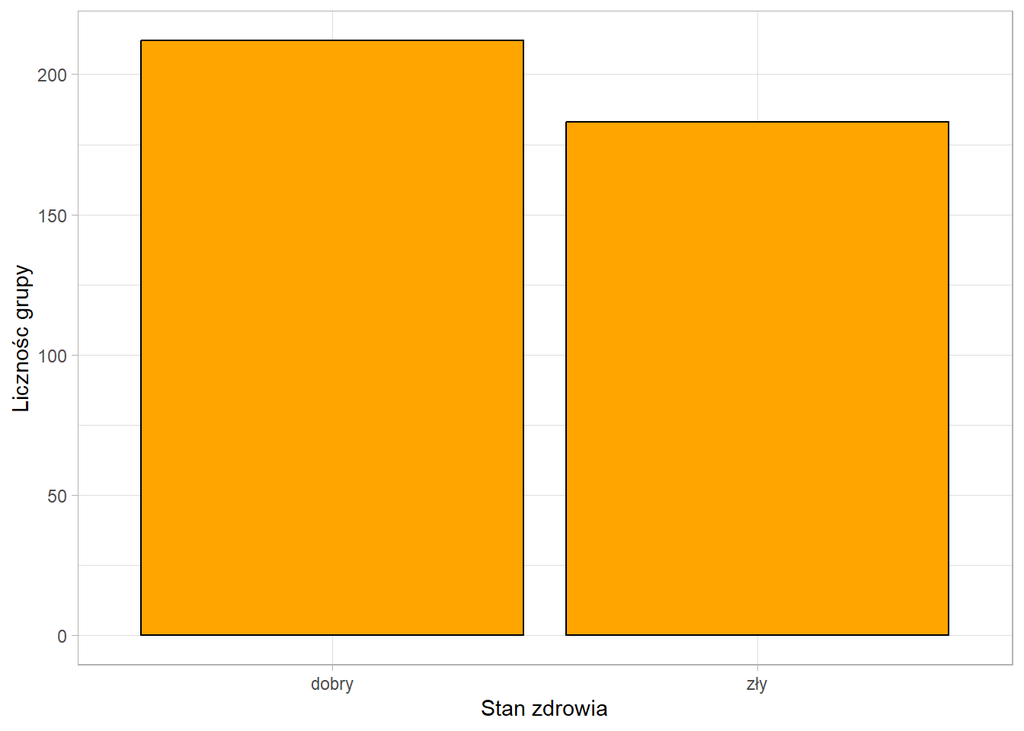

```r
ggplot()+
  geom_bar(aes(x=dane11$health),
           color="black",
           fill="orange")+
  labs(x="Stan zdrowia",
       y="Licznośc grupy")+
  theme_light()
```

Sprawdźmy czy ilość picia w weekend wpływa na zdrowie:

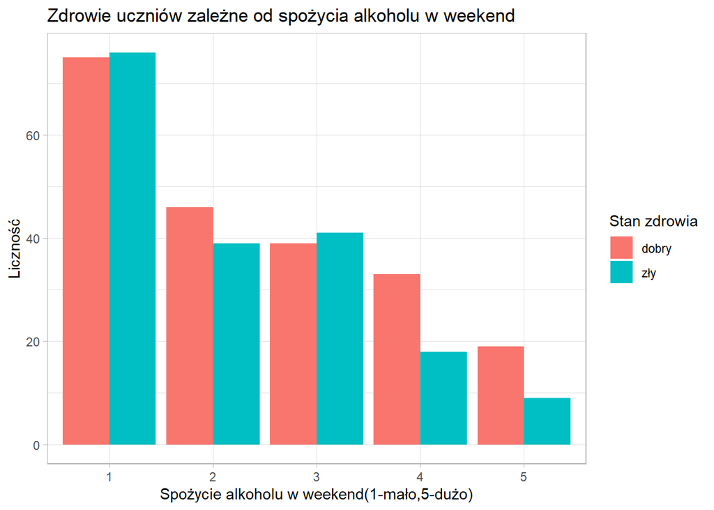

```r
ggplot()+
  geom_bar(aes(x=dane$Walc,
               fill=dane11$health),
           position = "dodge")+
  theme_light()+
  labs(title = "Zdrowie uczniów zależne od spożycia alkoholu w weekend",
       x="Spożycie alkoholu w weekend(1-mało,5-dużo)",
       y="Liczność",
       fill="Stan zdrowia")
```

Największe różnice widzimy w grupach `4` oraz `5`, czyli tam gdzie uczniowie spożywali najwięcej alkholu w weekend. Co ciekawe jest tam sporo uczniów z dobrym stanem zdrowia.

## Czy zdrowie wpływa na ocenę końcową

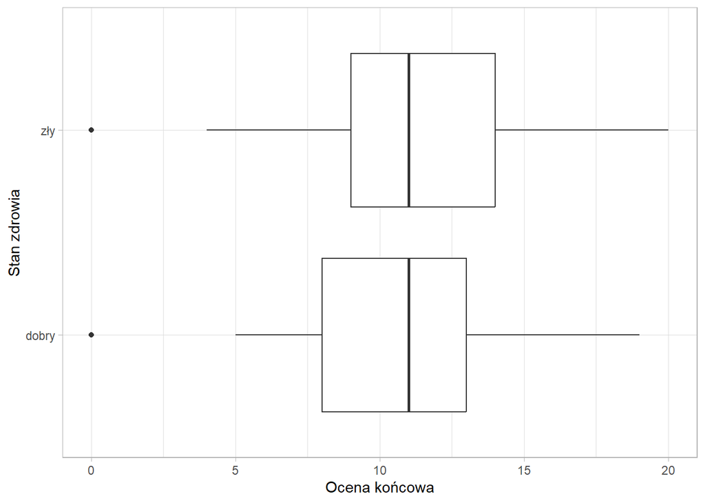

```r
ggplot(dane11)+
  geom_boxplot(aes(x=G3,
               y=health))+
  theme_light()+
  labs(x="Ocena końcowa",
       y="Stan zdrowia")
```

Nie ma dużej zależności między zdrowiem, a oceną końcową. Wręcz **można powiedzieć, że uczniowie ze złym stanem zdrowia poradzili sobie troszeczkę lepiej niż uczniowie z dobrym stanem zdrowia.**

Możemy sprawdzić jeszcze, jakby sytuacja wyglądała gdy weźmiemy tylko dwie graniczne grupy - z oceną zdrowia `1` oraz `5`. Sprawdźmy liczności tych grup:

```r
table(dane$health)
```

```
##
##   1   2   3   4   5
##  47  45  91  66 146
```

Jako że grupa `5` jest dużo bardziej liczna niż `1` wezmę grupę `4`.

```r
dane12<-dane%>%
  select(G3,health)%>%
  filter(health==1|health==4)%>%
  group_by(health)%>%
  summarise(liczba = n(),
            srednia = mean(G3),
            mediana = median(G3),
            odch.st = sd(G3))
dane12
```

```
## # A tibble: 2 × 5
##   health liczba srednia mediana odch.st
##   <fct>   <int>   <dbl>   <dbl>   <dbl>
## 1 1          47    11.9      13    4.35
## 2 4          66    10.1      10    4.87
```

Tutaj już widzimy ewidentą zależność - **uczniowie z bardzo złym stanem zdrowia poradzili sobie znacznie lepiej niż uczniowie z dobrym stanem zdrowia.**

## Czy ilość nauki wpływa na zdrowie

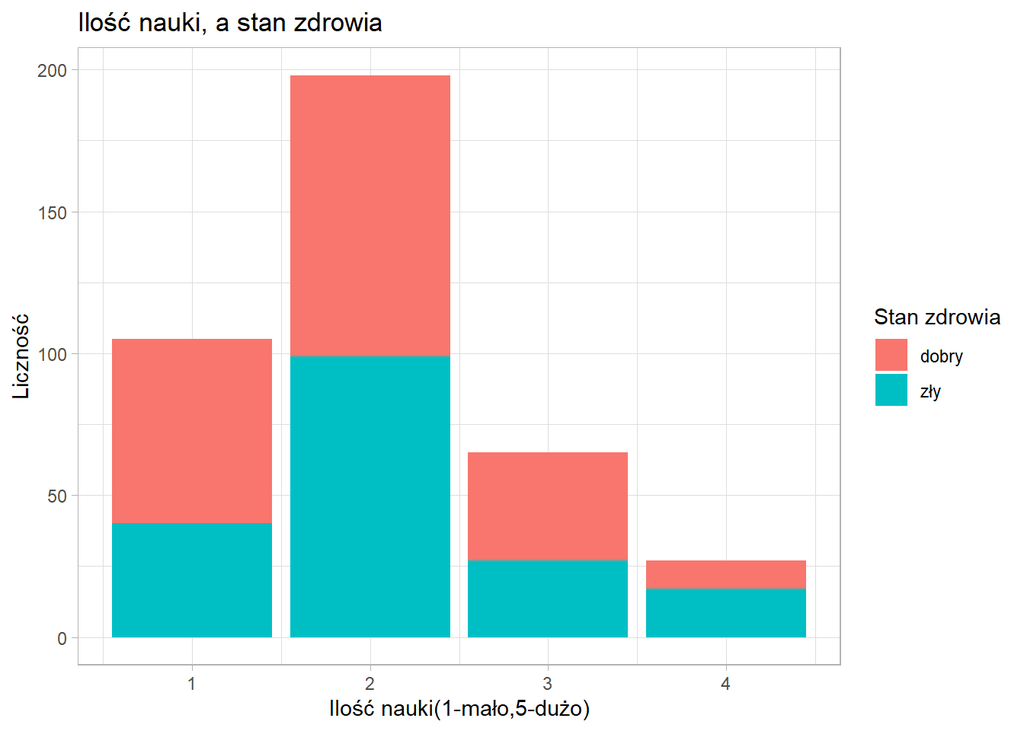

```r
ggplot()+
  geom_bar(aes(x=dane$studytime,
               fill=dane11$health))+
  theme_light()+
  labs(title = "Ilość nauki, a stan zdrowia",
       x="Ilość nauki(1-mało,5-dużo)",
       y="Liczność",
       fill="Stan zdrowia")
```

Występują niewielkie róznice w licznościach grup - w grupie która uczyła się najmniej mamy trochę więcej osób z dobrym stanem zdrowia, a w grupie która uczyła się najwięcej więcej niż połowa uczniów ma zły stan zdrowia, ale nie widać tutaj ewidentnych zależności, więc możemy powiedzieć że **ilość nauki raczej nie wpływa na zdrowie ucznia.**

## Czy ilość nauki wpływa na ocenę końcową

Sprawdźmy czy faktycznie więcej czasu spędzonego nad nauką przynosi rezultaty w postaci wyższej oceny końcowej.

Przypomnijmy jeszcze raz jakie są liczności poszczególnych grup atrybutu `studytime`:

```r
dane%>%
  group_by(studytime)%>%
  count()
```

```
## # A tibble: 4 × 2
## # Groups:   studytime [4]
##   studytime     n
##       <dbl> <int>
## 1         1   105
## 2         2   198
## 3         3    65
## 4         4    27
```

-‘1’ to <2 godziny

-‘2’ to od 2 do 5 godzin

-‘3’ to od 5 do 10 godzin

-‘4’ to >10 godzin

Jako że grupa uczniów, którzy uczyli się >10 godzin jest nieliczna to połącze ją z grupą ‘3’:

```r
dane0<-dane%>%
  select(studytime,G3)%>%
  mutate(studytime=ifelse(studytime==3|studytime==4,3,studytime))
```

Sprawdźmy teraz, czy więcej godzin nauki przynosi efekty w postaci wyższej oceny końcowej.

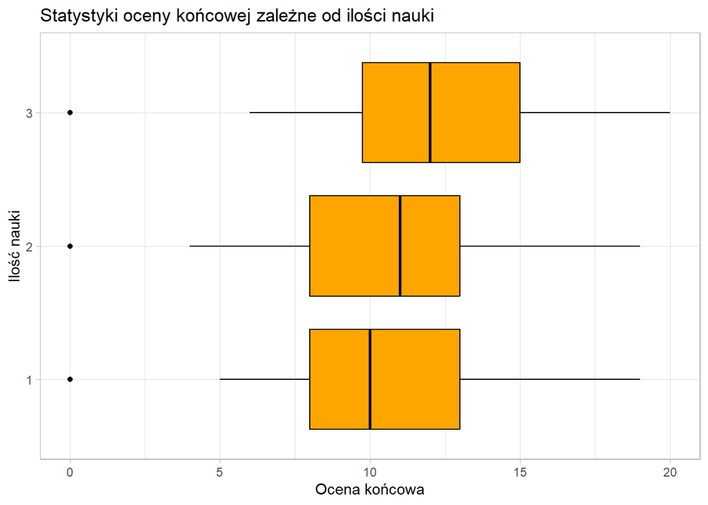

```r
ggplot(dane0,aes(y=factor(studytime),x=G3))+
  geom_boxplot(color="black",
               fill="orange")+
  labs(title = "Statystyki oceny końcowej zależne od ilości nauki",
       x="Ocena końcowa",
       y="Ilość nauki")+
  theme_light()
```

**Tak jak można się było spodziewać, więcej nauki w ciągu tygodnia przynosi efekty w postaci wyższych ocen końcowych.**

Potwierdźmy to jeszcze statystykami opisowymi:

```r
dane0%>%
  group_by(studytime)%>%
  summarise(średnia=mean(G3),
            odchylenie_standardowe=sd(G3),
            mediana=median(G3))
```

```
## # A tibble: 3 × 4
##   studytime średnia odchylenie_standardowe mediana
##       <dbl>   <dbl>                  <dbl>   <dbl>
## 1         1    10.0                   4.96      10
## 2         2    10.2                   4.22      11
## 3         3    11.4                   4.81      12
```

Sprawdźmy jeszcze, ile osób które uczyły się mniej niż 2 godziny nie zdało(zakładając, że trzeba mieć więcej niż 30%:

```r
dane0%>%
  select(studytime,G3)%>%
  filter(studytime==1)%>%
  count(G3<6)
```

```
## # A tibble: 2 × 2
##   `G3 < 6`     n
##   <lgl>    <int>
## 1 FALSE       88
## 2 TRUE        17
```

17 uczniów nie zdało semestru.A teraz sprawdźmy jak sytuacja ma się u osób, które uczyły się więcej niż 5 godzin:

```r
dane0%>%
  select(studytime,G3)%>%
  filter(studytime==3)%>%
  count(G3<6)
```

```
## # A tibble: 2 × 2
##   `G3 < 6`     n
##   <lgl>    <int>
## 1 FALSE       83
## 2 TRUE         9
```

Tutaj widzimy, że 9 uczniów nie zaliczyło semestru. Oczywiście trzeba wziąć pod uwagę to, że grupa tych uczniów była troszeczkę mniej liczna.

## Czy uczniowie korzystający z pomocy dostawali lepsze oceny

Postaram się teraz zbadać, czy uczniowie którzy korzystali z różnych pomocy naukowych oraz dodatkowych zajęć dostawali lepsze oceny. Potrzebne mi będą zmienne:

- `schoolsup` - dodatkowe wsparcie naukowe (tak lub nie )
- `paid` - dodatkowe płatne lekcje (tak lub nie )
- `famsup` - naukowe wsparcie od rodziny (tak lub nie )

Sprawdzę teraz ile uczniów otrzymuje wszystkie trzy pomoce naraz:

```r
(dane%>%
  select(schoolsup,paid,famsup)%>%
  filter(schoolsup=="yes"&paid=="yes"&famsup=="yes")%>%
   count())
```

```
## # A tibble: 1 × 1
##       n
##   <int>
## 1    19
```

Jest to niewielka ilość uczniów, dlatego pozbędę się w naszych dalszych rozważaniach zmiennej `schoolsup`.

```r
dane13<-dane%>%
  select(famrel,G3,paid,famsup)%>%
  filter(paid=="yes"&famsup=="yes")
```

```r
summary(dane13$G3)
```

```
##    Min. 1st Qu.  Median    Mean 3rd Qu.    Max.
##    0.00    9.00   11.00   10.84   13.00   19.00
```

Dla przypomnienia - statystyki całej populacji:

```r
summary(dane$G3)
```

```
##    Min. 1st Qu.  Median    Mean 3rd Qu.    Max.
##    0.00    8.00   11.00   10.42   14.00   20.00
```

**Wyniki są do siebie bardzo zbliżone - zależność jest zerowa.**